# D213_Task_1

## Research Question

We have been given revenue for a telecommunications company. Using the available data, the research question that we hope to answer is if we can use time series modeling to predict outcomes for the company.

The objective of this type of analysis is to use time series modeling on the dataset, consisting of revenue and days. By using this type of modeling, our outcome is we hope to be able to find patterns within the data. By using the patterns that we find, we can better predict future revenue and customer purchase habits.

## Method Justification

The assumption that we tie to stationarity within a time series model is that we assume the data is stationary. This means that over time, the data's mean, variance, and autocorrelation structures do not change. If we sample the first ten days or the last ten days, our samples should have identical covariances.

Autocorrelation is another part of the time series modeling that we encounter, it simply means that past values are correlation with present values.

## Data Prep

```python
#Importing packages
import numpy as np
import pandas as pd
import matplotlib.pyplot as plt
%matplotlib inline
import seaborn as sns
from dateutil.parser import parse
```

```python
#Importing time series
telco = pd.read_csv('teleco_time_series .csv')
telco
```

|  | Day | Revenue |
| --- | --- | --- |
| 0 | 1 | 0.000000 |
| 1 | 2 | 0.000793 |
| 2 | 3 | 0.825542 |
| 3 | 4 | 0.320332 |
| 4 | 5 | 1.082554 |
| ... | ... | ... |
| 726 | 727 | 16.931559 |
| 727 | 728 | 17.490666 |
| 728 | 729 | 16.803638 |
| 729 | 730 | 16.194813 |
| 730 | 731 | 16.620798 |

731 rows × 2 columns

```python
telco.set_index('Day',inplace=True)
```

```python
telco.index=pd.to_datetime(telco.index, unit = 'D', origin = '2015-01-01')
```

```python
telco.dropna(inplace=True)
```

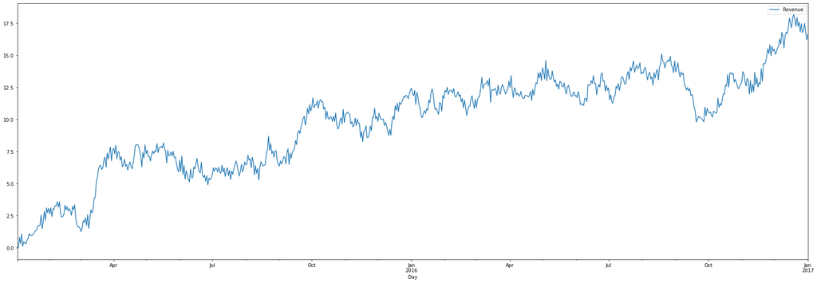

```python
#Plot of time series
telco.plot(figsize=(30, 10))
plt.show()
```

```python
#Testing the Stationarity of our model
from statsmodels.tsa.stattools import adfuller
print("Observations of Dickey-fuller test")
telcotest = adfuller(telco['Revenue'],autolag='AIC')
telcooutput=pd.Series(telcotest[0:4],index=['Test Statistic','p-value','#lags used','number of observations used'])
for key,value in telcotest[4].items():
    telcooutput['critical value (%s)'%key]= value
print(telcooutput)
```

```
Observations of Dickey-fuller test
Test Statistic                  -1.924612
p-value                          0.320573
#lags used                       1.000000
number of observations used    729.000000
critical value (1%)             -3.439352
critical value (5%)             -2.865513
critical value (10%)            -2.568886
dtype: float64
```

Our critical values for stationarity are: -3.4, -2.8, -2.5 while our test statistic is: -1.9. Viewing this output, we can determine that our data is not stationary as the test statistic is not under the critical values.

```python
#Making time series stationary
telco_stat = telco.diff().dropna()
telco_stat
```

| Day | Revenue |
| --- | --- |
| 2015-01-03 | 0.000793 |
| 2015-01-04 | 0.824749 |
| 2015-01-05 | -0.505210 |
| 2015-01-06 | 0.762222 |
| 2015-01-07 | -0.974900 |
| ... | ... |
| 2016-12-28 | 0.170280 |
| 2016-12-29 | 0.559108 |
| 2016-12-30 | -0.687028 |
| 2016-12-31 | -0.608824 |
| 2017-01-01 | 0.425985 |

730 rows × 1 columns

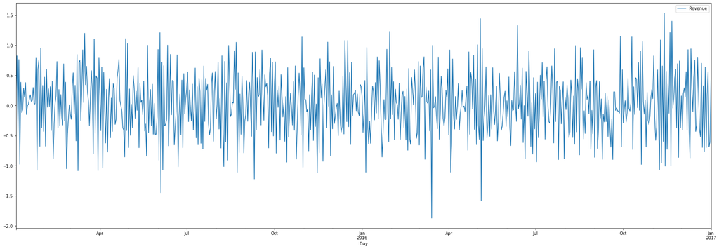

```python
#Plotting time series
telco_stat.plot(figsize=(30, 10))
plt.show()
```

```python
#Testing Stationarity
from statsmodels.tsa.stattools import adfuller
print("Observations of Dickey-fuller test")
telcotest = adfuller(telco_stat['Revenue'],autolag='AIC')
telcooutput=pd.Series(telcotest[0:4],index=['Test Statistic','p-value','#lags used','number of observations used'])
for key,value in telcotest[4].items():
    telcooutput['critical value (%s)'%key]= value
print(telcooutput)
```

```
Observations of Dickey-fuller test
Test Statistic                 -44.874527
p-value                          0.000000
#lags used                       0.000000
number of observations used    729.000000
critical value (1%)             -3.439352
critical value (5%)             -2.865513
critical value (10%)            -2.568886
dtype: float64
```

After further prep of the data, we can see that our test statistic is -44.8, much less than any our critical values.

```python
#Checking for nulls
telco_stat.isna().any()
```

```
Revenue    False
dtype: bool
```

```python
#Checking for duplicates
telco_stat.duplicated().any()
```

```
False
```

```python
#Creating training and testing data
telco_train = telco_stat.iloc[:364]
telco_test = telco_stat.iloc[365:]
```

```python
#Export cleaned data
telco_stat.to_csv('cleaned_data.csv', index = False)
```

## Model Identification and Analysis

```python
from statsmodels.tsa.seasonal import seasonal_decompose
result = seasonal_decompose(telco_stat['Revenue'], model='additive', period=1)
```

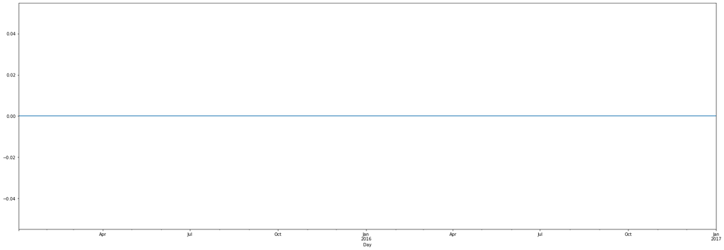

```python
#Seasonal Plot
result.seasonal.plot(figsize=(30, 10))
```

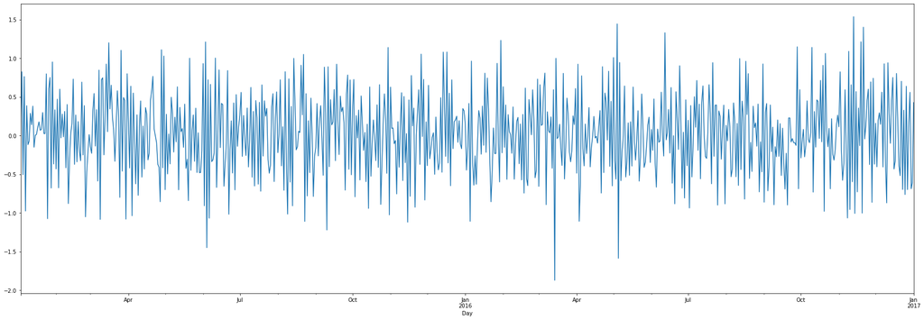

```python
#Trend Plot
result.trend.plot(figsize=(30, 10))
```

```python
#Compute a 7 day average
telcoavg = telco_stat.copy()
```

```python
telcoavg[ '7day' ] = telcoavg.Revenue.rolling( 7).mean()
```

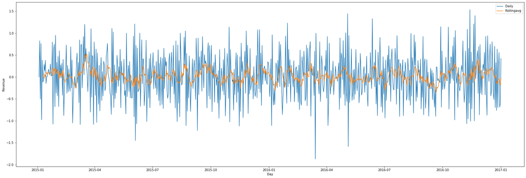

```python
#Rolling Average Plot
plt.figure( figsize = ( 30, 10))


sns.lineplot( x = 'Day',
             y = 'Revenue',
             data = telcoavg,
             label = 'Daily')


sns.lineplot( x = 'Day',
             y = '7day',
             data = telcoavg,
             label = 'Rollingavg')

plt.xlabel('Day')
```

We now have a graph of our average sales, along with the daily sales for our telco company.

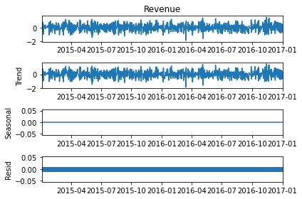

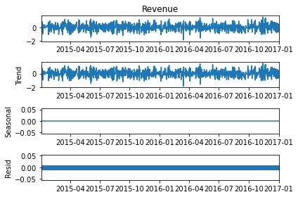

```python
#Decomposed time series
result.plot()
```

```python
from statsmodels.graphics.tsaplots import plot_acf
```

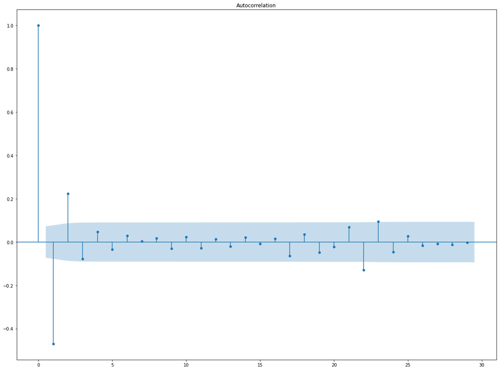

```python
#Autocorrelation Plot
fig = plot_acf(telco_stat)
fig.set_size_inches(20, 15)
plt.show(fig)
```

```python
from statsmodels.graphics.tsaplots import plot_pacf
```

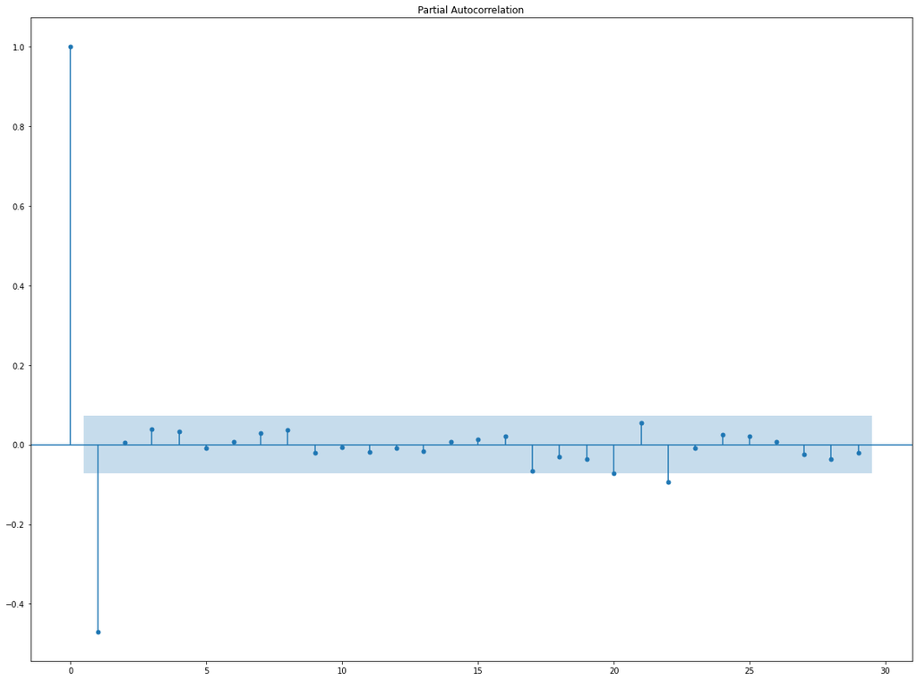

```python
#Partial Autocorrelation Plot
fig = plot_pacf(telco_stat)
fig.set_size_inches(20, 15)
plt.show(fig)
```

```
                               SARIMAX Results
==============================================================================
Dep. Variable:                Revenue   No. Observations:                  730
Model:                 ARIMA(5, 1, 0)   Log Likelihood                -545.622
Date:                Sat, 28 Aug 2021   AIC                           1103.243
Time:                        21:53:17   BIC                           1130.793
Sample:                    01-03-2015   HQIC                          1113.873
                         - 01-01-2017
Covariance Type:                  opg
==============================================================================
                 coef    std err          z      P>|z|      [0.025      0.975]
------------------------------------------------------------------------------
ar.L1         -1.2947      0.036    -35.703      0.000      -1.366      -1.224
ar.L2         -1.0175      0.057    -17.802      0.000      -1.130      -0.906
ar.L3         -0.7079      0.065    -10.935      0.000      -0.835      -0.581
ar.L4         -0.4271      0.058     -7.311      0.000      -0.542      -0.313
ar.L5         -0.1813      0.037     -4.882      0.000      -0.254      -0.109
sigma2         0.2609      0.015     17.960      0.000       0.232       0.289
===================================================================================
Ljung-Box (L1) (Q):                   0.74   Jarque-Bera (JB):                 3.05
Prob(Q):                              0.39   Prob(JB):                         0.22
Heteroskedasticity (H):               0.99   Skew:                            -0.12
Prob(H) (two-sided):                  0.92   Kurtosis:                         2.79
===================================================================================

Warnings:
[1] Covariance matrix calculated using the outer product of gradients (complex-step).
```

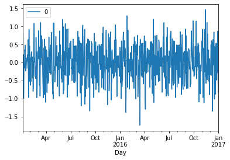

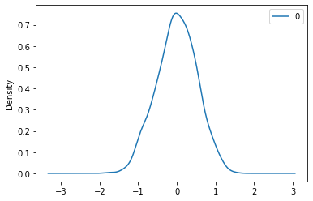

```
                0
count  730.000000
mean    -0.002052
std      0.511771
min     -1.734058
25%     -0.354040
50%      0.007621
75%      0.347918
max      1.460947
```

```python
# Arima Model
from statsmodels.tsa.arima.model import ARIMA
from pandas import DataFrame
# fit model
telco_stat.index = telco_stat.index.to_period('D')
model = ARIMA(telco_stat, order=(5,1,0), freq = "D")
model_fit = model.fit()
# summary of fit model
print(model_fit.summary())
# line plot of residuals
residuals = DataFrame(model_fit.resid)
residuals.plot()
plt.show()
# density plot of residuals
residuals.plot(kind='kde')
plt.show()
# summary stats of residuals
print(residuals.describe())
```

```python
#Predictions
from sklearn.metrics import mean_squared_error
from math import sqrt
X = telco_stat.values
size = int(len(X) * 0.66)
train, test = X[0:size], X[size:len(X)]
history = [x for x in train]
predictions = list()
# walk-forward validation
for t in range(len(test)):
	model = ARIMA(history, order=(5,1,0))
	model_fit = model.fit()
	output = model_fit.forecast()
	yhat = output[0]
	predictions.append(yhat)
	obs = test[t]
	history.append(obs)
	print('predicted=%f, expected=%f' % (yhat, obs))
# evaluate forecasts
rmse = sqrt(mean_squared_error(test, predictions))
print('Test RMSE: %.3f' % rmse)
```

```
predicted=0.073678, expected=-0.398402
predicted=0.493211, expected=0.442802
predicted=0.200065, expected=-0.650088
predicted=0.451605, expected=1.008159
predicted=-0.255253, expected=-0.324824
predicted=0.365546, expected=-0.562324
predicted=0.244546, expected=1.442980
predicted=-0.513372, expected=-1.585790
predicted=0.776759, expected=0.943729
predicted=-0.338858, expected=-0.583497
predicted=0.106102, expected=-0.212997
predicted=0.062260, expected=-0.003891
predicted=-0.167196, expected=0.640939
predicted=-0.455344, expected=-0.535783
predicted=0.334733, expected=-0.329183
predicted=-0.013814, expected=0.163790
predicted=-0.205994, expected=-0.513667
predicted=0.112459, expected=0.178902
predicted=-0.253228, expected=-0.394099
predicted=-0.128893, expected=0.628061
predicted=-0.390155, expected=-0.071771
predicted=0.037969, expected=-0.317071
predicted=0.135298, expected=-0.057014
predicted=-0.015031, expected=0.321697
predicted=-0.150852, expected=-0.589136
predicted=0.264832, expected=-0.280994
predicted=-0.094939, expected=0.537505
predicted=-0.425178, expected=0.143334
predicted=-0.051832, expected=-0.410972
predicted=0.184911, expected=-0.345691
predicted=-0.004449, expected=-0.126817
predicted=-0.084963, expected=0.137300
predicted=-0.171820, expected=0.237650
predicted=-0.230651, expected=-0.348350
predicted=0.031539, expected=0.079178
predicted=-0.104597, expected=-0.191498
predicted=0.038073, expected=0.473420
predicted=-0.176750, expected=-0.351148
predicted=0.157943, expected=-0.667049
predicted=0.153341, expected=0.083698
```

[output cut: 195 more lines]

```
predicted=-0.165041, expected=0.205935
predicted=0.225539, expected=-0.385952
predicted=0.362889, expected=-0.517971
predicted=0.162306, expected=0.701432
predicted=-0.269716, expected=-0.696344
predicted=0.331193, expected=0.327692
predicted=-0.275620, expected=-0.761868
predicted=0.097753, expected=0.637298
predicted=-0.415888, expected=-0.697778
predicted=0.198563, expected=0.170280
predicted=-0.309482, expected=0.559108
predicted=-0.283029, expected=-0.687028
predicted=0.240091, expected=-0.608824
predicted=0.151032, expected=0.425985
Test RMSE: 0.517
```

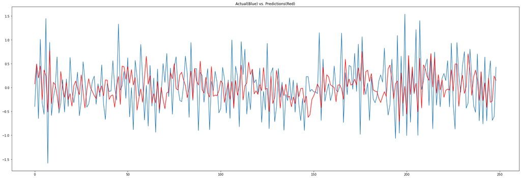

```python
# plot forecasts vs actual outcomes
plt.figure(figsize=(30,10))
plt.title('Actual(Blue) vs. Predictions(Red)')
plt.plot(test)
plt.plot(predictions, color='red')
plt.show()
```

## Data Summary and Implications

Due to the absence of seasonal variance within our data, the ARIMA model was chosen so the lack of seasonal variance did not skew the model.

Findings:

While our RMSE is not optimal, the outcome of this gives the telecommunications company a starting point to predict future sales. The more important fact is that the company and stakeholders can find patterns within the data, this tracks back to our original research question. By performing our data preparation, graphing, and analysis we can comfortably answer our question, that with the data provided, we can find patterns within the data. Business leaders can use our analysis to plan and strategize for future operations, along with that as more revenue data is provided, our RMSE number and strength of predictions will increase.